# In Class Problem Set 2

Marjorie Blanco

10/29/2018

# Problem Set 2: What determines wages?

What factors determine a person’s wage is of just importance for policy. Today we are do some simple analyses using a dataset on individual characteristics and wage outcomes in 1980. You can find the CVS dataset under data in Canvas (Wages).

## 1. Normal statistics

```
##       wage            hours             IQ             KWW
##  Min.   : 115.0   Min.   :20.00   Min.   : 50.0   Min.   :12.00
##  1st Qu.: 669.0   1st Qu.:40.00   1st Qu.: 92.0   1st Qu.:31.00
##  Median : 905.0   Median :40.00   Median :102.0   Median :37.00
##  Mean   : 957.9   Mean   :43.93   Mean   :101.3   Mean   :35.74
##  3rd Qu.:1160.0   3rd Qu.:48.00   3rd Qu.:112.0   3rd Qu.:41.00
##  Max.   :3078.0   Max.   :80.00   Max.   :145.0   Max.   :56.00
##
##       educ           exper           tenure            age
##  Min.   : 9.00   Min.   : 1.00   Min.   : 0.000   Min.   :28.00
##  1st Qu.:12.00   1st Qu.: 8.00   1st Qu.: 3.000   1st Qu.:30.00
##  Median :12.00   Median :11.00   Median : 7.000   Median :33.00
##  Mean   :13.47   Mean   :11.56   Mean   : 7.234   Mean   :33.08
##  3rd Qu.:16.00   3rd Qu.:15.00   3rd Qu.:11.000   3rd Qu.:36.00
##  Max.   :18.00   Max.   :23.00   Max.   :22.000   Max.   :38.00
##
##     married          black            south            urban
##  Min.   :0.000   Min.   :0.0000   Min.   :0.0000   Min.   :0.0000
##  1st Qu.:1.000   1st Qu.:0.0000   1st Qu.:0.0000   1st Qu.:0.0000
##  Median :1.000   Median :0.0000   Median :0.0000   Median :1.0000
##  Mean   :0.893   Mean   :0.1283   Mean   :0.3412   Mean   :0.7176
##  3rd Qu.:1.000   3rd Qu.:0.0000   3rd Qu.:1.0000   3rd Qu.:1.0000
##  Max.   :1.000   Max.   :1.0000   Max.   :1.0000   Max.   :1.0000
##
##       sibs           brthord           meduc           feduc
##  Min.   : 0.000   Min.   : 1.000   Min.   : 0.00   Min.   : 0.00
##  1st Qu.: 1.000   1st Qu.: 1.000   1st Qu.: 8.00   1st Qu.: 8.00
##  Median : 2.000   Median : 2.000   Median :12.00   Median :10.00
##  Mean   : 2.941   Mean   : 2.277   Mean   :10.68   Mean   :10.22
##  3rd Qu.: 4.000   3rd Qu.: 3.000   3rd Qu.:12.00   3rd Qu.:12.00
##  Max.   :14.000   Max.   :10.000   Max.   :18.00   Max.   :18.00
##                   NA's   :83       NA's   :78      NA's   :194
##      lwage
##  Min.   :4.745
##  1st Qu.:6.506
##  Median :6.808
##  Mean   :6.779
##  3rd Qu.:7.056
##  Max.   :8.032
##
```

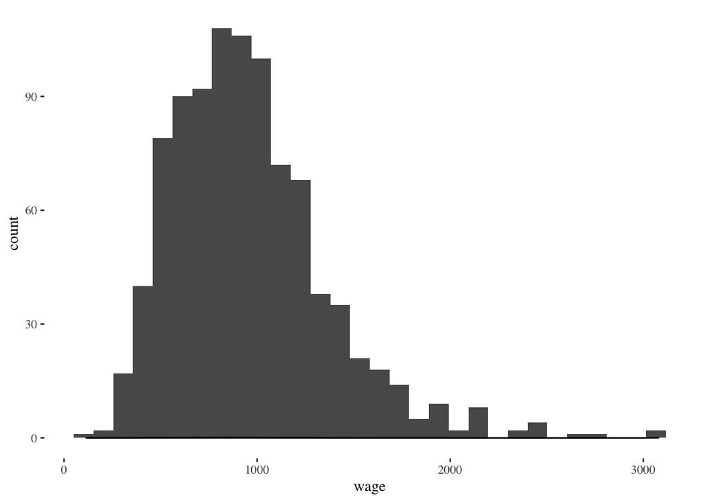

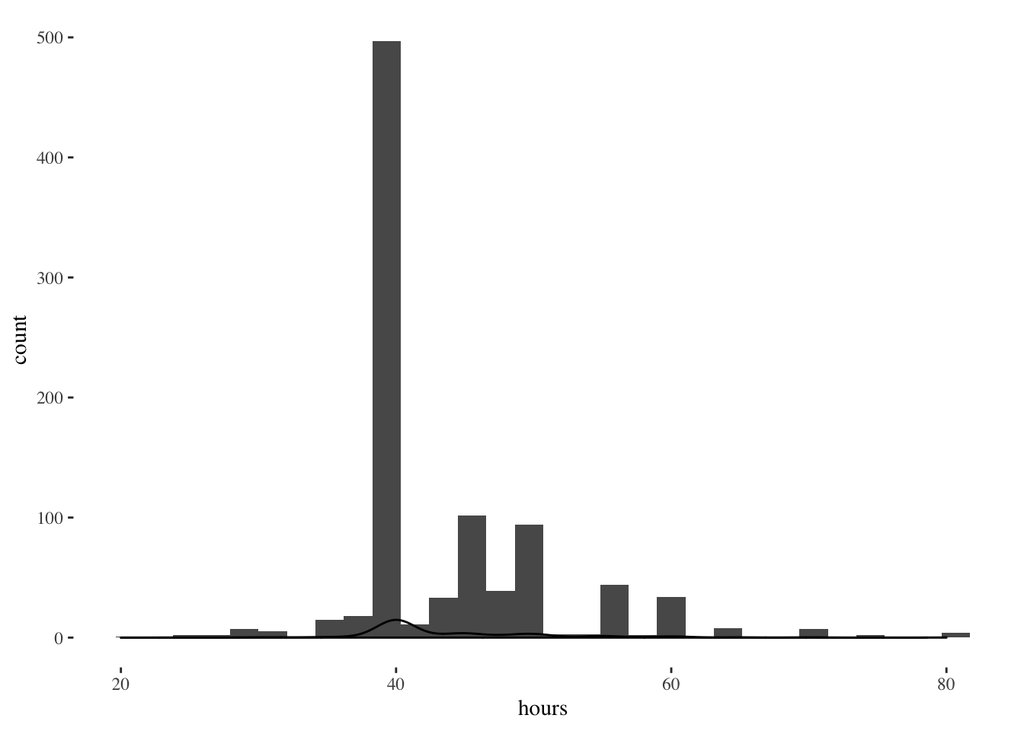

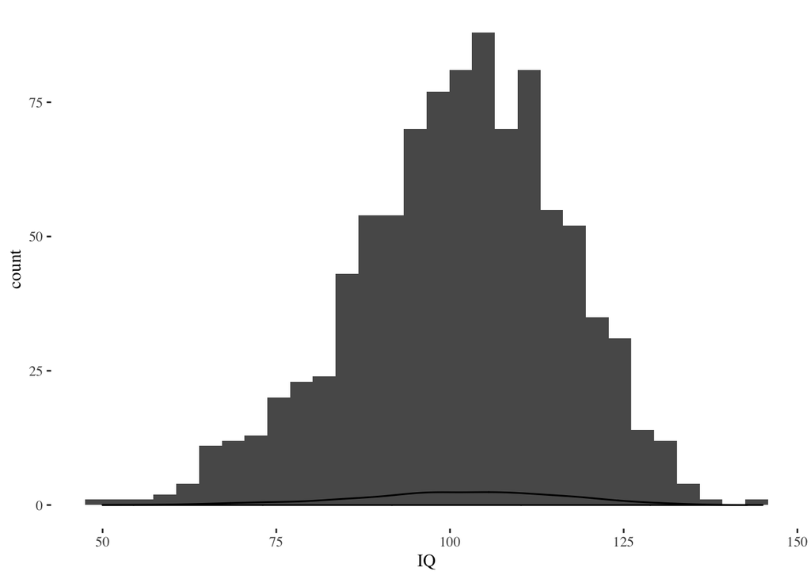

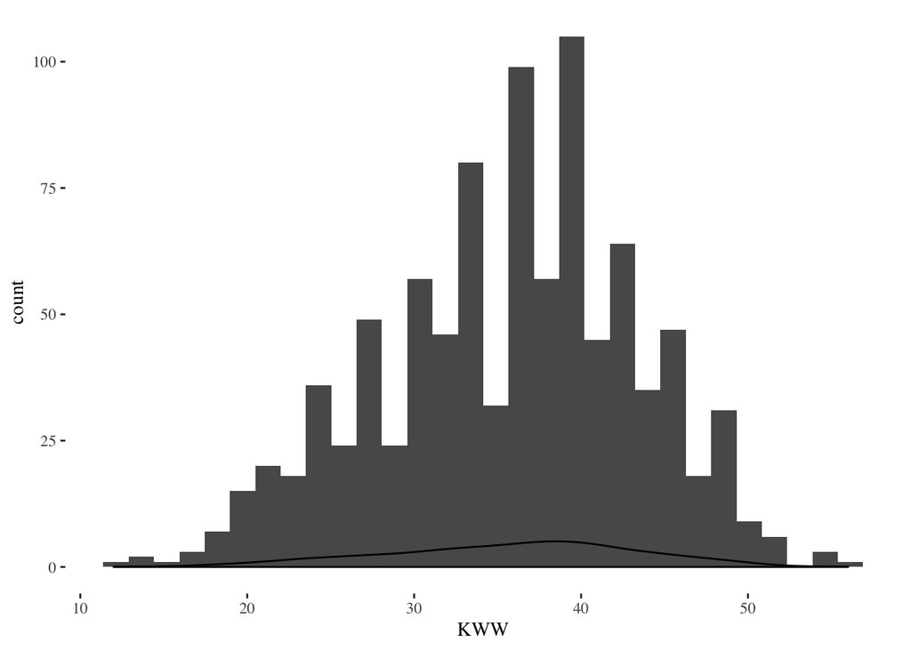

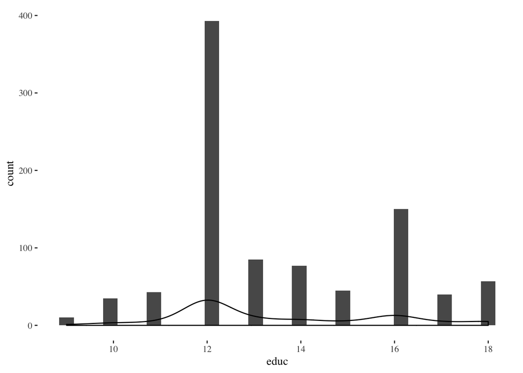

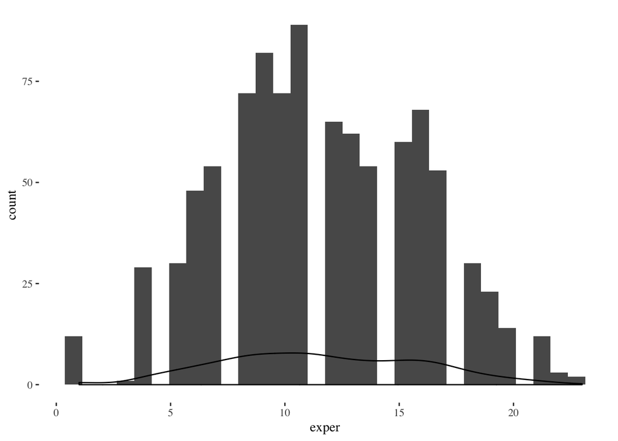

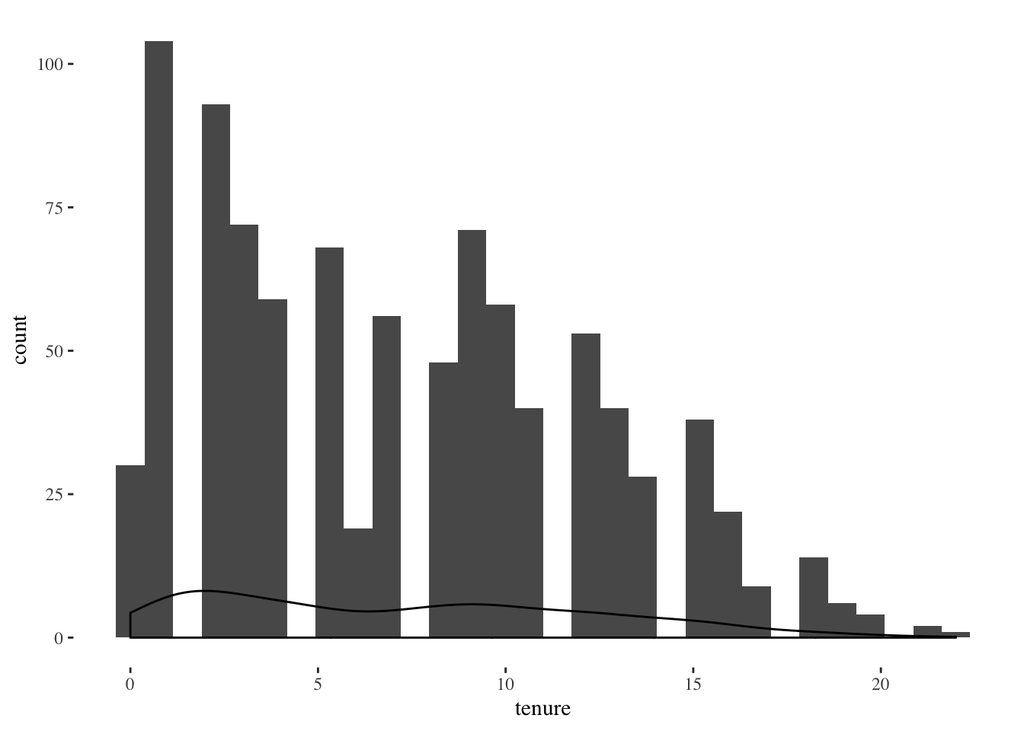

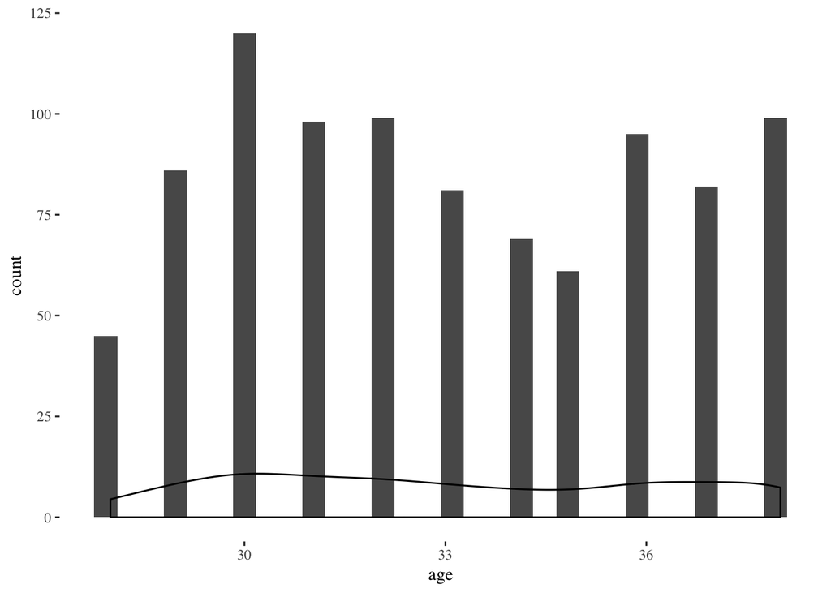

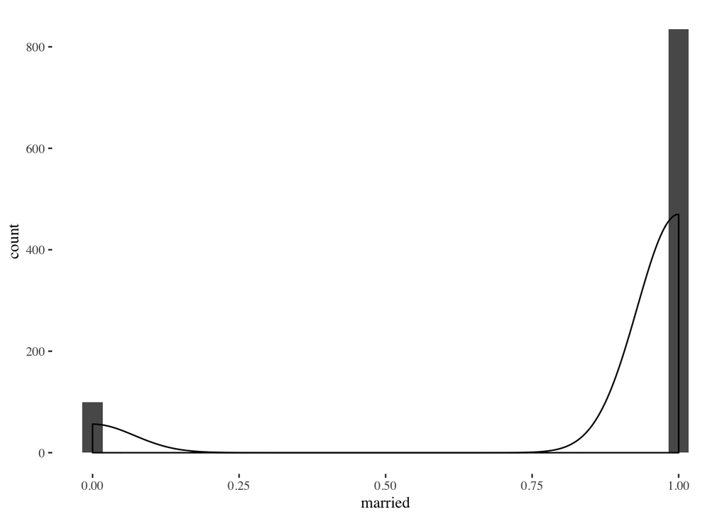

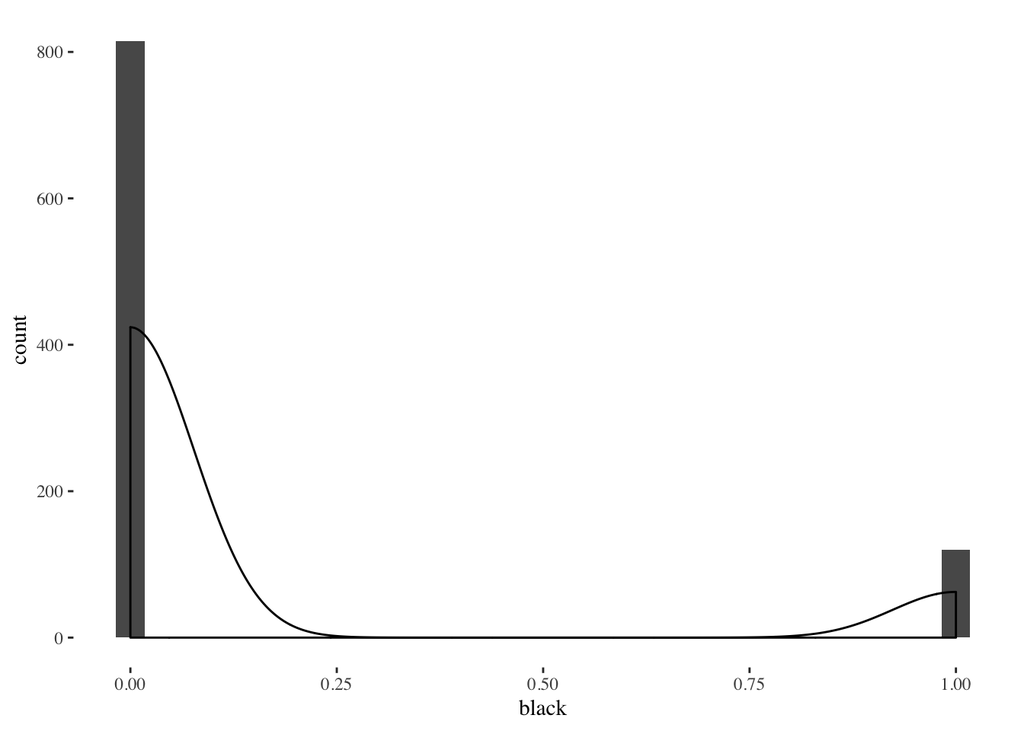

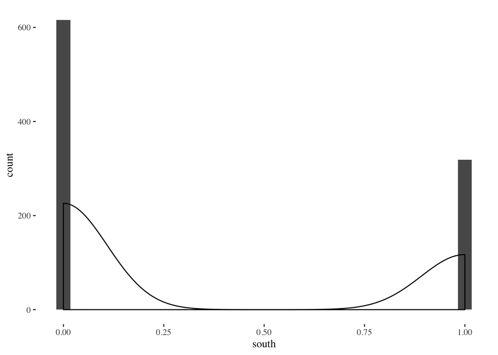

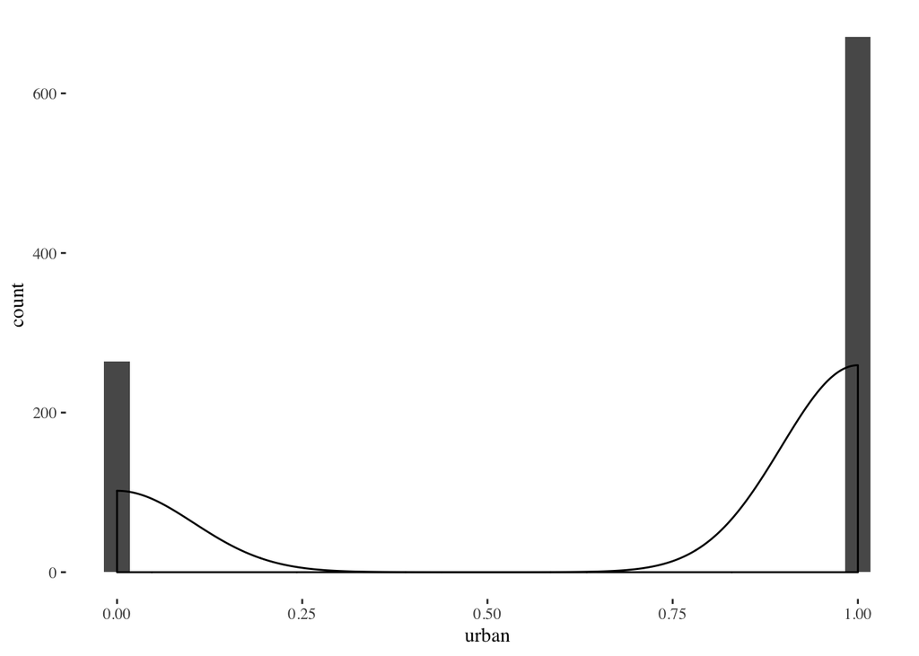

[5 more figures not shown]

The various variables are highly skewed and many missing data (NAs)

## 2. Correlation

Find the correlations between the variables we will use. What stands out here?

```r
#                          Coefficient, r
# Strength of Association   Positive    Negative
# None                    0.0 to 0.3  0.0 to -0.3
# Weak                      0.3 to 0.5 -0.3 to -0.5
# Moderate                0.5 to 0.7 -0.5 to -0.7
# Strong                  0.7 to 1.0 -0.7 to -1.0
```

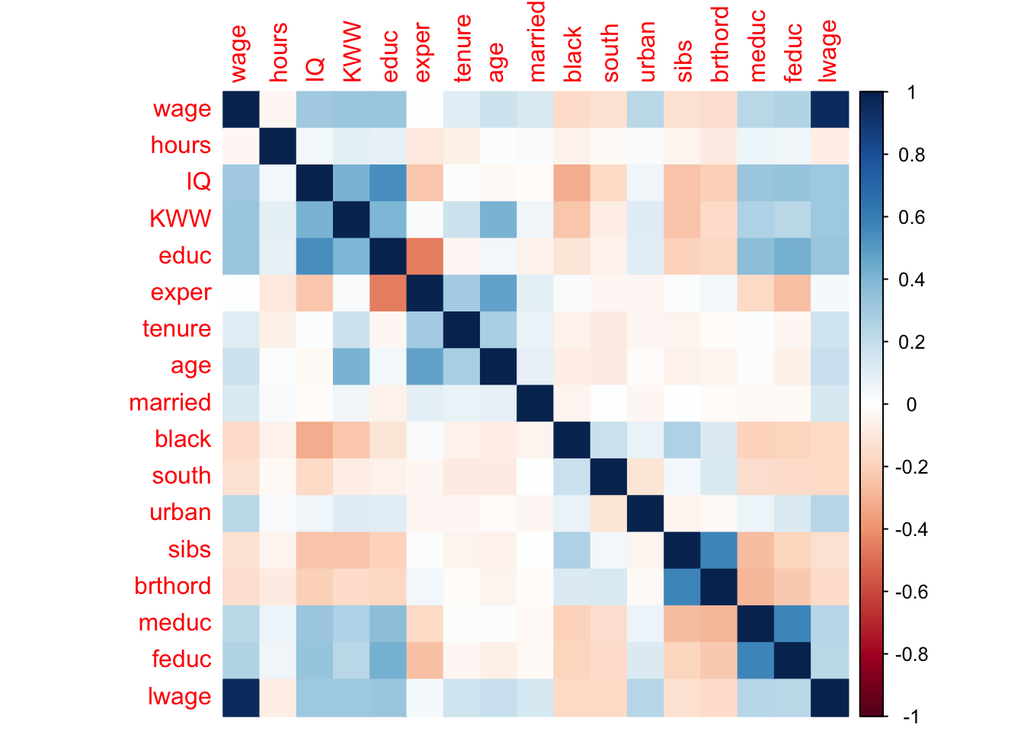

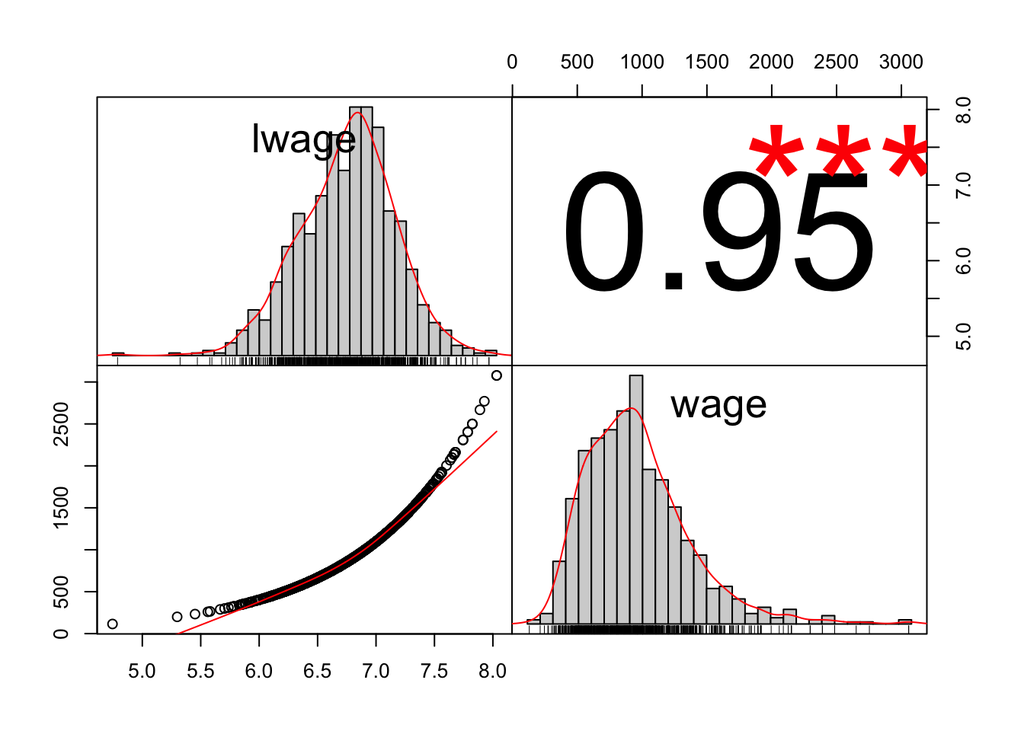

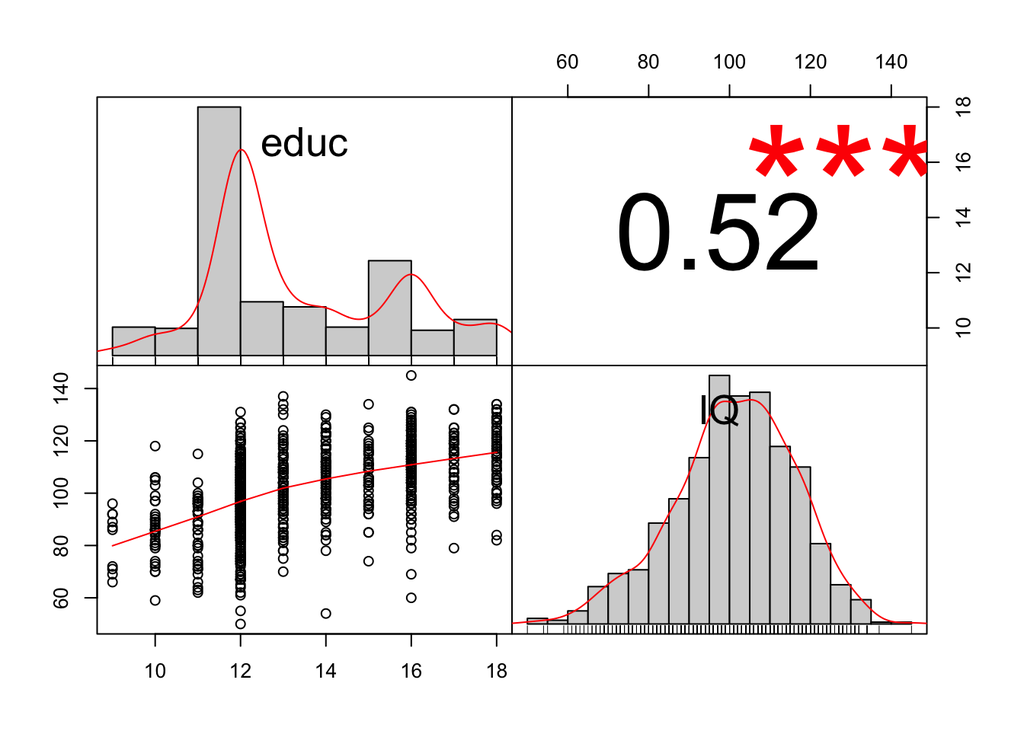

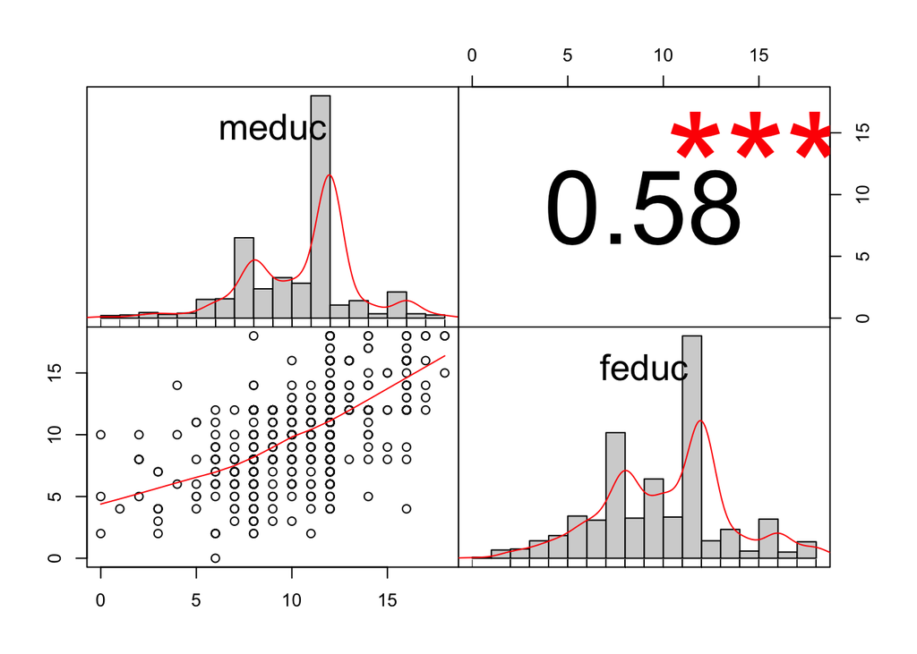

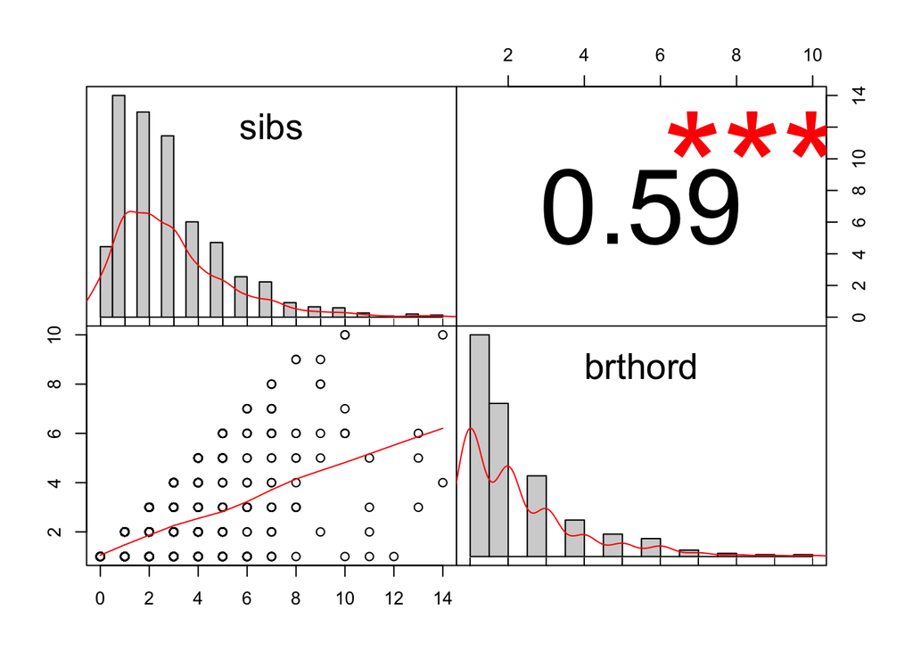

```
##     row  column        cor p
## 1    IQ    educ  0.5156970 0
## 2  educ   exper -0.4555731 0
## 3 exper     age  0.4953298 0
## 4  sibs brthord  0.5939138 0
## 5 meduc   feduc  0.5764948 0
## 6  wage   lwage  0.9531412 0
```

- lwage and wage are strongly correlated
- educ and IQ are moderately correlated
- meduc and feduc are moderately correlated
- sibs and brthord are moderately correlated
- exper and age are weakly correlated
- educ and exper are weakly correlated

## 3. Regression 1 (Hours and IQ)

Run a regression with hours and IQ scoreas the explanatory variables. What are the coefficients for both and their interpretation (remember to include whether they are statistically significant).

```r
fit1 <- lm(wage~hours+IQ, wages)
summary(fit1)
```

```
##
## Call:
## lm(formula = wage ~ hours + IQ, data = wages)
##
## Residuals:
##    Min     1Q Median     3Q    Max
## -888.1 -257.0  -46.4  204.3 2046.9
##
## Coefficients:
##             Estimate Std. Error t value Pr(>|t|)
## (Intercept) 190.3847   110.9182   1.716   0.0864 .
## hours        -1.8194     1.7474  -1.041   0.2981
## IQ            8.3675     0.8386   9.977   <2e-16 ***
## ---
## Signif. codes:  0 '***' 0.001 '**' 0.01 '*' 0.05 '.' 0.1 ' ' 1
##
## Residual standard error: 384.7 on 932 degrees of freedom
## Multiple R-squared:  0.09659,    Adjusted R-squared:  0.09465
## F-statistic: 49.82 on 2 and 932 DF,  p-value: < 2.2e-16
```

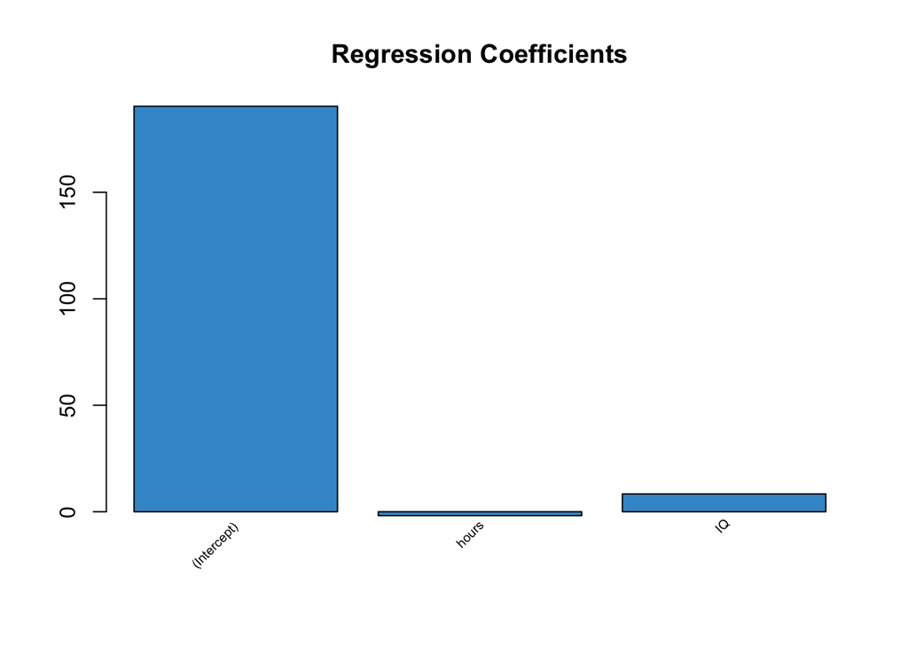

```r
plot_coeffs(fit1)
```

This means that if `hours` differed by one unit, wage will differ by -1.8193551 units, on average, while holding `IQ` constant.

This means that if `IQ` differed by one unit, wage will differ by 8.3675385 units, on average, while holding `hours` constant. This is statistically significant at the 0.001 percent level.

We would expect an average monthly earning (`wage`) to be 190.3846723

`hours` is not statistically significant since p-value is 0.3

`IQ` is statistically significant since p-value is 0

The model is signficant

The Adjusted R2 value is 0.0946. This tells us that 9.46% of the variation in monthly earnings, as quantified by wage, is reduced by taking into account hours and IQ.

## 4. Regression 2 (Education)

Run the same regression as in Q3, but now add education as an additional explanatory variable. What are the coefficients and their interpretations (remember to include whether they are statistically significant).

```r
fit2 <- lm(wage~hours+IQ+educ, wages)
summary(fit2)
```

```
##
## Call:
## lm(formula = wage ~ hours + IQ + educ, data = wages)
##
## Residuals:
##    Min     1Q Median     3Q    Max
## -873.5 -256.5  -39.7  200.6 2075.4
##
## Coefficients:
##             Estimate Std. Error t value Pr(>|t|)
## (Intercept) -31.1321   113.7586  -0.274    0.784
## hours        -2.5096     1.7132  -1.465    0.143
## IQ            5.1821     0.9557   5.422 7.50e-08 ***
## educ         42.6527     6.5584   6.504 1.28e-10 ***
## ---
## Signif. codes:  0 '***' 0.001 '**' 0.01 '*' 0.05 '.' 0.1 ' ' 1
##
## Residual standard error: 376.5 on 931 degrees of freedom
## Multiple R-squared:  0.1358, Adjusted R-squared:  0.1331
## F-statistic: 48.78 on 3 and 931 DF,  p-value: < 2.2e-16
```

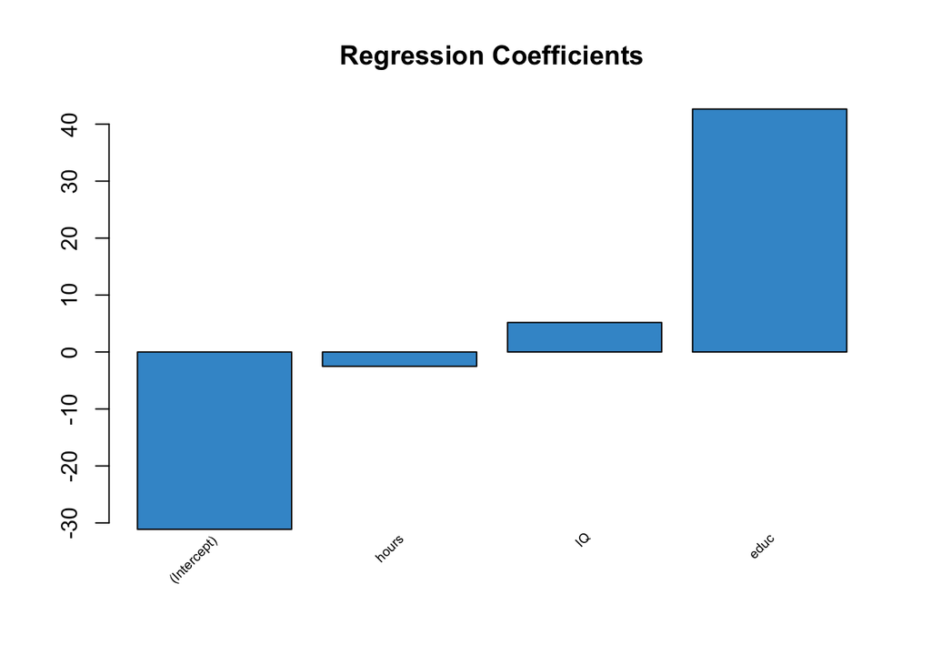

```r
plot_coeffs(fit2)
```

This means that if `hours` differed by one unit, wage will differ by -2.5095841 units, on average.

This means that if `IQ` differed by one unit, wage will differ by 5.1821051 units, on average.

This means that if `educ` differed by one unit, wage will differ by 42.6527422 units, on average.

We would expect an average monthly earning (`wage`) to be -31.132084

`hours` is not statistically significant since p-value is 0.14

`IQ` is statistically significant since p-value is 0

`educ` is statistically significant since p-value is 0

The model is signficant

The Adjusted R2 value is 0.1331. This tells us that 13.31% of the variation in monthly earnings, as quantified by wage, is reduced by taking into account hours, IQ and educ.

## 5. Explain

Explain why the coefficients change between the two regression. Are the changes in the direction you would expect?

```r
fit21 <- lm(wage~educ, wages)
summary(fit21)
```

```
##
## Call:
## lm(formula = wage ~ educ, data = wages)
##
## Residuals:
##     Min      1Q  Median      3Q     Max
## -877.38 -268.63  -38.38  207.05 2148.26
##
## Coefficients:
##             Estimate Std. Error t value Pr(>|t|)
## (Intercept)  146.952     77.715   1.891   0.0589 .
## educ          60.214      5.695  10.573   <2e-16 ***
## ---
## Signif. codes:  0 '***' 0.001 '**' 0.01 '*' 0.05 '.' 0.1 ' ' 1
##
## Residual standard error: 382.3 on 933 degrees of freedom
## Multiple R-squared:  0.107,  Adjusted R-squared:  0.106
## F-statistic: 111.8 on 1 and 933 DF,  p-value: < 2.2e-16
```

```r
fit22 <- lm(wage~IQ, wages)
summary(fit22)
```

```
##
## Call:
## lm(formula = wage ~ IQ, data = wages)
##
## Residuals:
##    Min     1Q Median     3Q    Max
## -898.7 -256.5  -47.3  201.1 2072.6
##
## Coefficients:
##             Estimate Std. Error t value Pr(>|t|)
## (Intercept) 116.9916    85.6415   1.366    0.172
## IQ            8.3031     0.8364   9.927   <2e-16 ***
## ---
## Signif. codes:  0 '***' 0.001 '**' 0.01 '*' 0.05 '.' 0.1 ' ' 1
##
## Residual standard error: 384.8 on 933 degrees of freedom
## Multiple R-squared:  0.09554,    Adjusted R-squared:  0.09457
## F-statistic: 98.55 on 1 and 933 DF,  p-value: < 2.2e-16
```

```r
fit23 <- lm(wage~IQ+educ, wages)
summary(fit23)
```

```
##
## Call:
## lm(formula = wage ~ IQ + educ, data = wages)
##
## Residuals:
##     Min      1Q  Median      3Q     Max
## -860.29 -251.00  -35.31  203.98 2110.38
##
## Coefficients:
##              Estimate Std. Error t value Pr(>|t|)
## (Intercept) -128.8899    92.1823  -1.398    0.162
## IQ             5.1380     0.9558   5.375 9.66e-08 ***
## educ          42.0576     6.5498   6.421 2.15e-10 ***
## ---
## Signif. codes:  0 '***' 0.001 '**' 0.01 '*' 0.05 '.' 0.1 ' ' 1
##
## Residual standard error: 376.7 on 932 degrees of freedom
## Multiple R-squared:  0.1339, Adjusted R-squared:  0.132
## F-statistic: 72.02 on 2 and 932 DF,  p-value: < 2.2e-16
```

IQ and education are positively correlated, and IQ and wage are also positively correlated. I suspect the coefficient in the bivariate model to be biased/overestimated. This is confirmed by running the regression including `IQ` and `educ`.

The coefficient of `educ` decreased from 60.2142832 to 42.0576187. The bias in the bivariate model is large. The coefficient of `IQ` decreased from 8.3030643 to 5.1379576. The bias in the bivariate model is large.

## 6. Regression 3 (Experience and Tenure)

Run a regression with hours, IQs core, education, age, experience, and tenureas the explanatory variables. Interpret the results.

```r
fit3 <- lm(wage~hours+IQ+educ+age+exper+tenure, wages)
summary(fit3)
```

```
##
## Call:
## lm(formula = wage ~ hours + IQ + educ + age + exper + tenure,
##     data = wages)
##
## Residuals:
##     Min      1Q  Median      3Q     Max
## -846.40 -242.68  -44.56  189.42 2159.86
##
## Coefficients:
##              Estimate Std. Error t value Pr(>|t|)
## (Intercept) -736.7637   171.6533  -4.292 1.96e-05 ***
## hours         -2.2974     1.6796  -1.368  0.17170
## IQ             5.1015     0.9391   5.432 7.10e-08 ***
## educ          52.4772     7.2788   7.210 1.16e-12 ***
## age           12.5442     4.7210   2.657  0.00802 **
## exper          9.7844     3.7399   2.616  0.00904 **
## tenure         6.0879     2.5000   2.435  0.01507 *
## ---
## Signif. codes:  0 '***' 0.001 '**' 0.01 '*' 0.05 '.' 0.1 ' ' 1
##
## Residual standard error: 367.9 on 928 degrees of freedom
## Multiple R-squared:  0.1775, Adjusted R-squared:  0.1722
## F-statistic: 33.37 on 6 and 928 DF,  p-value: < 2.2e-16
```

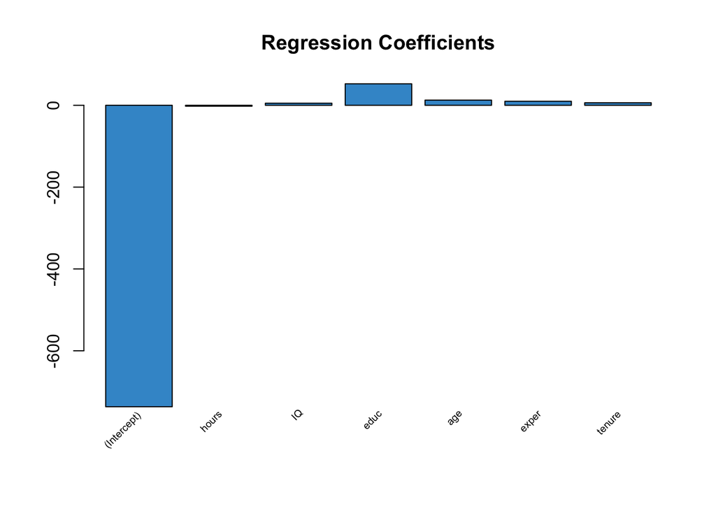

```r
plot_coeffs(fit3)
```

This means that if `hours` differed by one unit wage will differ by -2.2973718 units, on average.

This means that if `IQ` differed by one unit wage will differ by 5.101527 units, on average.

This means that if `educ` differed by one unit wage will differ by 52.477224 units, on average.

This means that if `age` differed by one unit wage will differ by 12.544197 units, on average.

This means that if `exper` differed by one unit wage will differ by 9.7844395 units, on average.

This means that if `tenure` differed by one unit wage will differ by 6.0879239 units, on average.

We would expect an average monthly earning (`wage`) to be -736.7636598

`hours` is not statistically significant since p-value is 0.17

`IQ` is statistically significant since p-value is 0

`educ` is statistically significant since p-value is 0

`age` is statistically significant since p-value is 0.01

`exper` is statistically significant since p-value is 0.01

`tenure` is statistically significant since p-value is 0.02

The model is signficant

The Adjusted R2 value is 0.1722. This tells us that 17.22% of the variation in monthly earnings, as quantified by wage, is reduced by taking into account hours, IQ, educ, age, exper, and tenure.

## 7. Explain

Explain why the coefficients change from the model in Q4.Does this make sense and why? (Hint: think what is behind the correlations you observed)

The coefficient for `hours` changed from -2.5095841 to -2.2973718. This is not a significant change.

The coefficient for `IQ` changed from 5.1821051 to 5.101527. This is not a significant change.

The coefficient for `educ` changed from 42.6527422 to 52.477224. This is a significant change.

```r
fit31 <- lm(wage~educ, wages)
summary(fit31)
```

```
##
## Call:
## lm(formula = wage ~ educ, data = wages)
##
## Residuals:
##     Min      1Q  Median      3Q     Max
## -877.38 -268.63  -38.38  207.05 2148.26
##
## Coefficients:
##             Estimate Std. Error t value Pr(>|t|)
## (Intercept)  146.952     77.715   1.891   0.0589 .
## educ          60.214      5.695  10.573   <2e-16 ***
## ---
## Signif. codes:  0 '***' 0.001 '**' 0.01 '*' 0.05 '.' 0.1 ' ' 1
##
## Residual standard error: 382.3 on 933 degrees of freedom
## Multiple R-squared:  0.107,  Adjusted R-squared:  0.106
## F-statistic: 111.8 on 1 and 933 DF,  p-value: < 2.2e-16
```

```r
fit32 <- lm(wage~age, wages)
summary(fit32)
```

```
##
## Call:
## lm(formula = wage ~ age, data = wages)
##
## Residuals:
##     Min      1Q  Median      3Q     Max
## -777.86 -288.70  -50.53  196.58 2203.24
##
## Coefficients:
##             Estimate Std. Error t value Pr(>|t|)
## (Intercept)  283.483    139.782   2.028   0.0428 *
## age           20.389      4.207   4.846 1.47e-06 ***
## ---
## Signif. codes:  0 '***' 0.001 '**' 0.01 '*' 0.05 '.' 0.1 ' ' 1
##
## Residual standard error: 399.6 on 933 degrees of freedom
## Multiple R-squared:  0.02456,    Adjusted R-squared:  0.02351
## F-statistic: 23.49 on 1 and 933 DF,  p-value: 1.472e-06
```

```r
fit33 <- lm(wage~exper, wages)
summary(fit33)
```

```
##
## Call:
## lm(formula = wage ~ exper, data = wages)
##
## Residuals:
##     Min      1Q  Median      3Q     Max
## -842.43 -289.13  -52.84  201.86 2120.17
##
## Coefficients:
##             Estimate Std. Error t value Pr(>|t|)
## (Intercept) 955.6049    37.4111  25.543   <2e-16 ***
## exper         0.2024     3.0261   0.067    0.947
## ---
## Signif. codes:  0 '***' 0.001 '**' 0.01 '*' 0.05 '.' 0.1 ' ' 1
##
## Residual standard error: 404.6 on 933 degrees of freedom
## Multiple R-squared:  4.795e-06,  Adjusted R-squared:  -0.001067
## F-statistic: 0.004474 on 1 and 933 DF,  p-value: 0.9467
```

```r
fit34 <- lm(wage~age+exper, wages)
summary(fit34)
```

```
##
## Call:
## lm(formula = wage ~ age + exper, data = wages)
##
## Residuals:
##     Min      1Q  Median      3Q     Max
## -757.16 -279.14  -50.82  207.14 2224.32
##
## Coefficients:
##             Estimate Std. Error t value Pr(>|t|)
## (Intercept)  177.225    144.789   1.224  0.22125
## age           26.830      4.827   5.559 3.55e-08 ***
## exper         -9.239      3.429  -2.694  0.00718 **
## ---
## Signif. codes:  0 '***' 0.001 '**' 0.01 '*' 0.05 '.' 0.1 ' ' 1
##
## Residual standard error: 398.2 on 932 degrees of freedom
## Multiple R-squared:  0.03209,    Adjusted R-squared:  0.03002
## F-statistic: 15.45 on 2 and 932 DF,  p-value: 2.501e-07
```

```r
fit35 <- lm(wage~educ+exper, wages)
summary(fit35)
```

```
##
## Call:
## lm(formula = wage ~ educ + exper, data = wages)
##
## Residuals:
##     Min      1Q  Median      3Q     Max
## -924.38 -252.74  -40.88  198.16 2165.70
##
## Coefficients:
##             Estimate Std. Error t value Pr(>|t|)
## (Intercept) -272.528    107.263  -2.541   0.0112 *
## educ          76.216      6.297  12.104  < 2e-16 ***
## exper         17.638      3.162   5.578 3.18e-08 ***
## ---
## Signif. codes:  0 '***' 0.001 '**' 0.01 '*' 0.05 '.' 0.1 ' ' 1
##
## Residual standard error: 376.3 on 932 degrees of freedom
## Multiple R-squared:  0.1359, Adjusted R-squared:  0.134
## F-statistic: 73.26 on 2 and 932 DF,  p-value: < 2.2e-16
```

The coefficient for `age` increased from 20.388695 to 26.8304713. The bias in the bivariate model is large.

The coefficient of `exper` decreased from 0.2024031 to -9.2390588. The bias in the bivariate model is large.

The coefficient of `exper` increased from 0.2024031 to 17.6377699. The bias in the bivariate model is large.

The coefficient for `educ` increased from 60.2142832 to 76.2163886. The bias in the bivariate model is large.

## 8. F-test

What does the F-test tell you about the model in Q6? What about the R2 and adjusted R2?

The model is significant

The R2 value is 0.1775. The Adjusted R2 value is 0.1722. This tells us that 17.22% of the variation in monthly earnings, as quantified by wage, is reduced by taking into account hours, IQ, educ, age, exper, and tenure.

## 9. Drop tenure and hours

Can we drop tenure and hours? (Do a joint test). What are the results and how do we interpret them?

```r
fit4 <- lm(wage~IQ+educ+age+exper, wages)
summary(fit4)
```

```
##
## Call:
## lm(formula = wage ~ IQ + educ + age + exper, data = wages)
##
## Residuals:
##     Min      1Q  Median      3Q     Max
## -871.69 -243.85  -43.11  182.09 2178.50
##
## Coefficients:
##              Estimate Std. Error t value Pr(>|t|)
## (Intercept) -871.9720   159.7874  -5.457 6.21e-08 ***
## IQ             5.2423     0.9384   5.586 3.04e-08 ***
## educ          52.0962     7.2994   7.137 1.92e-12 ***
## age           14.1408     4.6634   3.032  0.00249 **
## exper         11.2010     3.7181   3.013  0.00266 **
## ---
## Signif. codes:  0 '***' 0.001 '**' 0.01 '*' 0.05 '.' 0.1 ' ' 1
##
## Residual standard error: 369.1 on 930 degrees of freedom
## Multiple R-squared:  0.1702, Adjusted R-squared:  0.1666
## F-statistic: 47.68 on 4 and 930 DF,  p-value: < 2.2e-16
```

```r
anova(fit3, fit4)
```

```
## Analysis of Variance Table
##
## Model 1: wage ~ hours + IQ + educ + age + exper + tenure
## Model 2: wage ~ IQ + educ + age + exper
##   Res.Df       RSS Df Sum of Sq      F  Pr(>F)
## 1    928 125612051
## 2    930 126725573 -2  -1113522 4.1133 0.01665 *
## ---
## Signif. codes:  0 '***' 0.001 '**' 0.01 '*' 0.05 '.' 0.1 ' ' 1
```

```r
Hnull <- c("tenure = 0", "hours = 0")
linearHypothesis(fit3, Hnull)
```

```
## Linear hypothesis test
##
## Hypothesis:
## tenure = 0
## hours = 0
##
## Model 1: restricted model
## Model 2: wage ~ hours + IQ + educ + age + exper + tenure
##
##   Res.Df       RSS Df Sum of Sq      F  Pr(>F)
## 1    930 126725573
## 2    928 125612051  2   1113522 4.1133 0.01665 *
## ---
## Signif. codes:  0 '***' 0.001 '**' 0.01 '*' 0.05 '.' 0.1 ' ' 1
```

## 10 Experience and tenure effect

```r
Hnull <- c("tenure = exper")
linearHypothesis(fit3, Hnull)
```

```
## Linear hypothesis test
##
## Hypothesis:
## - exper  + tenure = 0
##
## Model 1: restricted model
## Model 2: wage ~ hours + IQ + educ + age + exper + tenure
##
##   Res.Df       RSS Df Sum of Sq      F Pr(>F)
## 1    929 125693864
## 2    928 125612051  1     81813 0.6044 0.4371
```

Can you rule out that the effect of experience overall and tenure at the current job have the same effect on wage?(

The coefficient of `IQ` changed from 5.101527 to 5.2423364. The change is not significant.

The coefficient of `age` increased from 12.544197 to 14.1408302. The change is not significant.

The coefficient of `exper` increased from 9.7844395 to 11.2010241. The change is not significant.

The Adjusted R2 value changed from 0.1722 to 0.1666.

## 11 Regression 4 (Parental Education)

If you have time, try to add parental education to the last model. Think about what changes. Also, try some joint hypotheses (for example, parental education have similar effect; difference between age and experience).

```r
fit5 <- lm(wage~IQ+educ+age+exper+meduc+feduc, wages)
summary(fit5)
```

```
##
## Call:
## lm(formula = wage ~ IQ + educ + age + exper + meduc + feduc,
##     data = wages)
##
## Residuals:
##     Min      1Q  Median      3Q     Max
## -789.51 -237.11  -46.77  186.05 2135.91
##
## Coefficients:
##             Estimate Std. Error t value Pr(>|t|)
## (Intercept) -884.522    180.303  -4.906 1.15e-06 ***
## IQ             4.670      1.131   4.130 4.05e-05 ***
## educ          41.302      8.710   4.742 2.56e-06 ***
## age           14.293      5.432   2.631  0.00869 **
## exper         13.204      4.390   3.008  0.00272 **
## meduc          6.789      6.104   1.112  0.26639
## feduc         12.403      5.366   2.311  0.02110 *
## ---
## Signif. codes:  0 '***' 0.001 '**' 0.01 '*' 0.05 '.' 0.1 ' ' 1
##
## Residual standard error: 370.8 on 715 degrees of freedom
##   (213 observations deleted due to missingness)
## Multiple R-squared:  0.1815, Adjusted R-squared:  0.1746
## F-statistic: 26.42 on 6 and 715 DF,  p-value: < 2.2e-16
```

```r
Hnull <- c("meduc = feduc")
linearHypothesis(fit5, Hnull)
```

```
## Linear hypothesis test
##
## Hypothesis:
## meduc - feduc = 0
##
## Model 1: restricted model
## Model 2: wage ~ IQ + educ + age + exper + meduc + feduc
##
##   Res.Df      RSS Df Sum of Sq      F Pr(>F)
## 1    716 98330376
## 2    715 98286073  1     44303 0.3223 0.5704
```

```r
Hnull <- c("age = exper")
linearHypothesis(fit5, Hnull)
```

```
## Linear hypothesis test
##
## Hypothesis:
## age - exper = 0
##
## Model 1: restricted model
## Model 2: wage ~ IQ + educ + age + exper + meduc + feduc
##
##   Res.Df      RSS Df Sum of Sq      F Pr(>F)
## 1    716 98288230
## 2    715 98286073  1    2157.1 0.0157 0.9003
```

- meduc and feduc are moderately correlated

`IQ` is statistically significant since p-value is 0

`educ` is statistically significant since p-value is 0

`age` is statistically significant since p-value is 0.01

`exper` is statistically significant since p-value is 0

`feduc` is statistically significant since p-value is 0.02

`meduc` is not statistically significant since p-value is 0.27

```r
fit6 <- lm(wage~IQ+educ+age+exper+feduc, wages)
summary(fit6)
```

```
##
## Call:
## lm(formula = wage ~ IQ + educ + age + exper + feduc, data = wages)
##
## Residuals:
##     Min      1Q  Median      3Q     Max
## -772.83 -238.07  -44.03  186.60 2139.82
##
## Coefficients:
##             Estimate Std. Error t value Pr(>|t|)
## (Intercept) -887.246    176.533  -5.026 6.30e-07 ***
## IQ             4.919      1.105   4.453 9.78e-06 ***
## educ          41.250      8.480   4.865 1.40e-06 ***
## age           15.021      5.297   2.836  0.00469 **
## exper         13.251      4.273   3.101  0.00200 **
## feduc         15.125      4.614   3.278  0.00109 **
## ---
## Signif. codes:  0 '***' 0.001 '**' 0.01 '*' 0.05 '.' 0.1 ' ' 1
##
## Residual standard error: 368.6 on 735 degrees of freedom
##   (194 observations deleted due to missingness)
## Multiple R-squared:  0.1807, Adjusted R-squared:  0.1751
## F-statistic: 32.42 on 5 and 735 DF,  p-value: < 2.2e-16
```

```r
Hnull <- c("feduc = 0", "meduc = 0")
linearHypothesis(fit5, Hnull)
```

```
## Linear hypothesis test
##
## Hypothesis:
## feduc = 0
## meduc = 0
##
## Model 1: restricted model
## Model 2: wage ~ IQ + educ + age + exper + meduc + feduc
##
##   Res.Df      RSS Df Sum of Sq      F   Pr(>F)
## 1    717 99915367
## 2    715 98286073  2   1629294 5.9263 0.002801 **
## ---
## Signif. codes:  0 '***' 0.001 '**' 0.01 '*' 0.05 '.' 0.1 ' ' 1
```

The Adjusted R2 for changed from 0.1746 to 0.1751. The model is significant and all explanatory variables are signficant.

`IQ` is statistically significant since p-value is 0

`educ` is statistically significant since p-value is 0

`age` is statistically significant since p-value is 0

`exper` is statistically significant since p-value is 0

`feduc` is statistically significant since p-value is 0

## Stepwise

```r
wages <- wages  %>% dplyr::select(-lwage) %>%na.omit()
# Fit the full model
full.model <- lm(wage ~., data = wages)
# Stepwise regression model
step.model <- stepAIC(full.model, direction = "both",
trace = FALSE)
summary(step.model)
```

```
##
## Call:
## lm(formula = wage ~ hours + IQ + KWW + educ + exper + age + married +
##     black + urban + feduc, data = wages)
##
## Residuals:
##     Min      1Q  Median      3Q     Max
## -867.13 -212.87  -41.46  157.70 2049.01
##
## Coefficients:
##             Estimate Std. Error t value Pr(>|t|)
## (Intercept) -743.578    215.062  -3.458 0.000581 ***
## hours         -4.234      1.946  -2.176 0.029914 *
## IQ             3.374      1.223   2.760 0.005944 **
## KWW            4.668      2.382   1.960 0.050473 .
## educ          38.656      8.980   4.305 1.93e-05 ***
## exper         10.540      4.393   2.399 0.016717 *
## age           10.237      5.981   1.712 0.087454 .
## married      178.960     46.397   3.857 0.000126 ***
## black        -97.083     54.392  -1.785 0.074744 .
## urban        178.486     31.262   5.709 1.72e-08 ***
## feduc         13.197      4.761   2.772 0.005732 **
## ---
## Signif. codes:  0 '***' 0.001 '**' 0.01 '*' 0.05 '.' 0.1 ' ' 1
##
## Residual standard error: 354.3 on 652 degrees of freedom
## Multiple R-squared:  0.252,  Adjusted R-squared:  0.2405
## F-statistic: 21.96 on 10 and 652 DF,  p-value: < 2.2e-16
```

```r
step.model <- stepAIC(full.model, direction = "backward",
trace = FALSE)
summary(step.model)
```

```
##
## Call:
## lm(formula = wage ~ hours + IQ + KWW + educ + exper + age + married +
##     black + urban + feduc, data = wages)
##
## Residuals:
##     Min      1Q  Median      3Q     Max
## -867.13 -212.87  -41.46  157.70 2049.01
##
## Coefficients:
##             Estimate Std. Error t value Pr(>|t|)
## (Intercept) -743.578    215.062  -3.458 0.000581 ***
## hours         -4.234      1.946  -2.176 0.029914 *
## IQ             3.374      1.223   2.760 0.005944 **
## KWW            4.668      2.382   1.960 0.050473 .
## educ          38.656      8.980   4.305 1.93e-05 ***
## exper         10.540      4.393   2.399 0.016717 *
## age           10.237      5.981   1.712 0.087454 .
## married      178.960     46.397   3.857 0.000126 ***
## black        -97.083     54.392  -1.785 0.074744 .
## urban        178.486     31.262   5.709 1.72e-08 ***
## feduc         13.197      4.761   2.772 0.005732 **
## ---
## Signif. codes:  0 '***' 0.001 '**' 0.01 '*' 0.05 '.' 0.1 ' ' 1
##
## Residual standard error: 354.3 on 652 degrees of freedom
## Multiple R-squared:  0.252,  Adjusted R-squared:  0.2405
## F-statistic: 21.96 on 10 and 652 DF,  p-value: < 2.2e-16
```

```r
step.model <- stepAIC(full.model, direction = "forward",
trace = FALSE)
summary(step.model)
```

```
##
## Call:
## lm(formula = wage ~ hours + IQ + KWW + educ + exper + tenure +
##     age + married + black + south + urban + sibs + brthord +
##     meduc + feduc, data = wages)
##
## Residuals:
##     Min      1Q  Median      3Q     Max
## -812.38 -207.81  -43.22  168.91 2047.32
##
## Coefficients:
##             Estimate Std. Error t value Pr(>|t|)
## (Intercept) -676.890    227.469  -2.976 0.003032 **
## hours         -4.391      1.953  -2.248 0.024899 *
## IQ             3.089      1.235   2.501 0.012630 *
## KWW            4.673      2.413   1.936 0.053293 .
## educ          38.146      9.029   4.225 2.73e-05 ***
## exper          9.767      4.478   2.181 0.029525 *
## tenure         2.747      2.922   0.940 0.347486
## age            8.865      6.035   1.469 0.142312
## married      177.051     46.444   3.812 0.000151 ***
## black        -96.187     56.207  -1.711 0.087503 .
## south        -21.698     31.051  -0.699 0.484940
## urban        178.488     31.543   5.659 2.29e-08 ***
## sibs           8.509      7.952   1.070 0.285044
## brthord      -17.090     11.681  -1.463 0.143951
## meduc          6.839      6.227   1.098 0.272485
## feduc          9.117      5.450   1.673 0.094840 .
## ---
## Signif. codes:  0 '***' 0.001 '**' 0.01 '*' 0.05 '.' 0.1 ' ' 1
##
## Residual standard error: 354.1 on 647 degrees of freedom
## Multiple R-squared:  0.2584, Adjusted R-squared:  0.2412
## F-statistic: 15.03 on 15 and 647 DF,  p-value: < 2.2e-16
```